# R Notebook

### Relación entre variables:

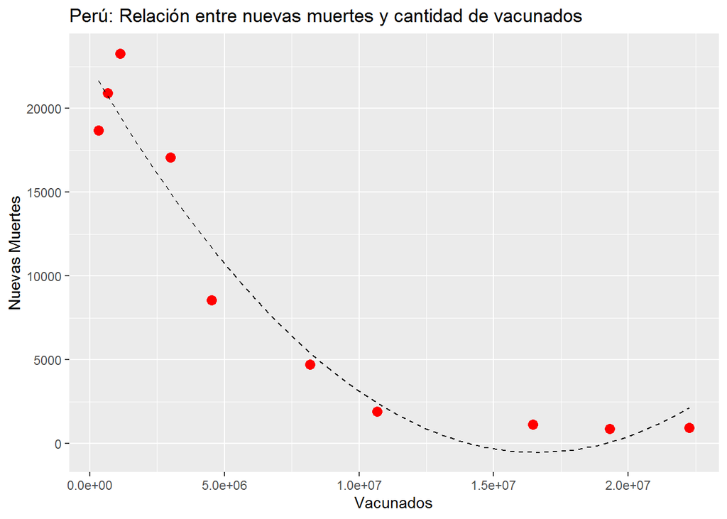

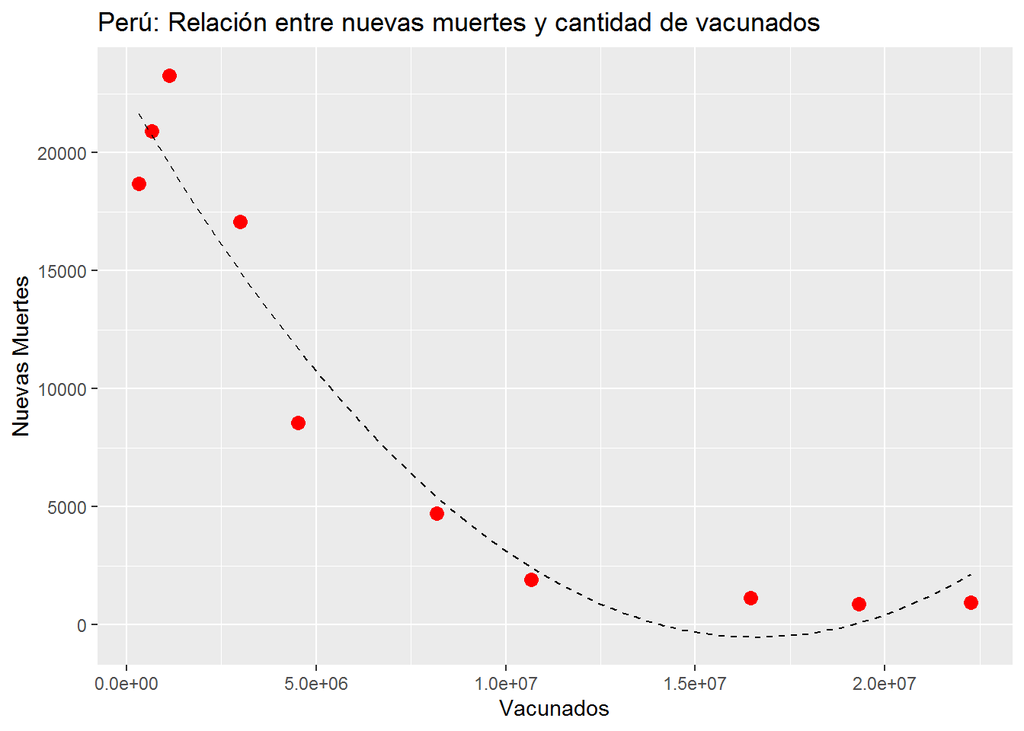

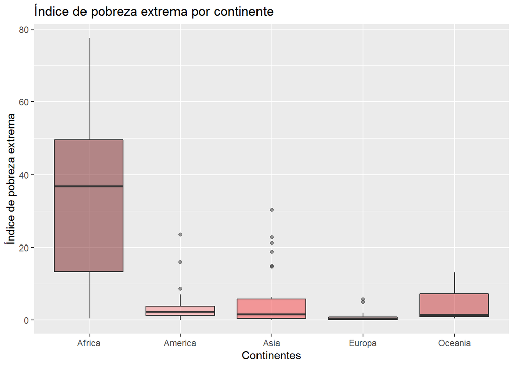

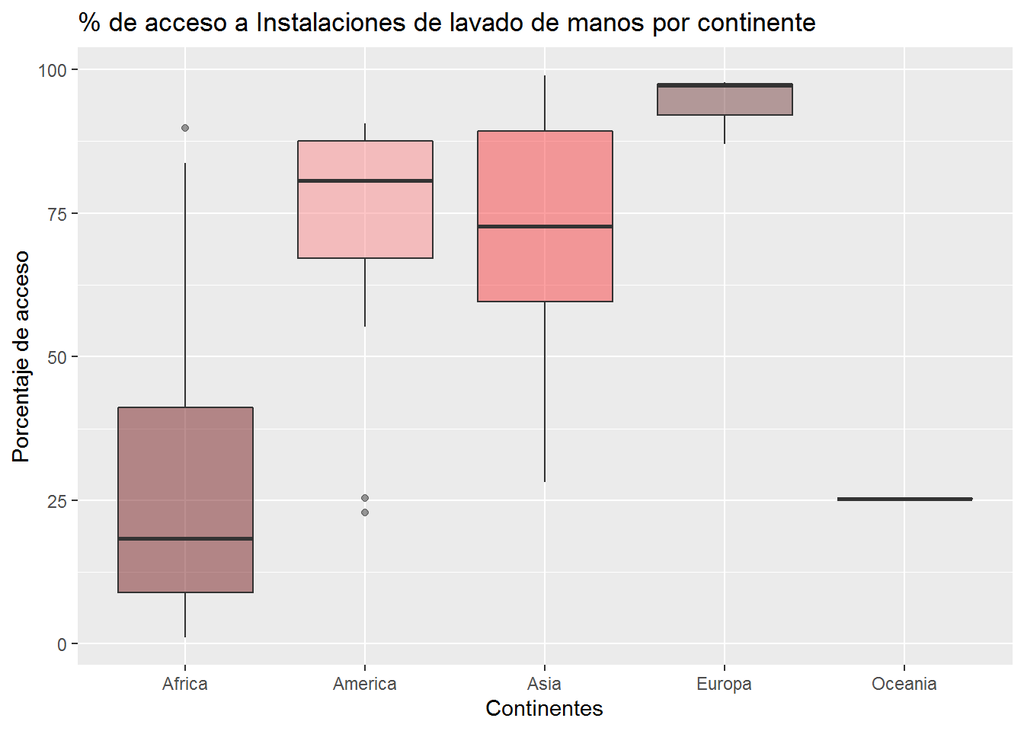

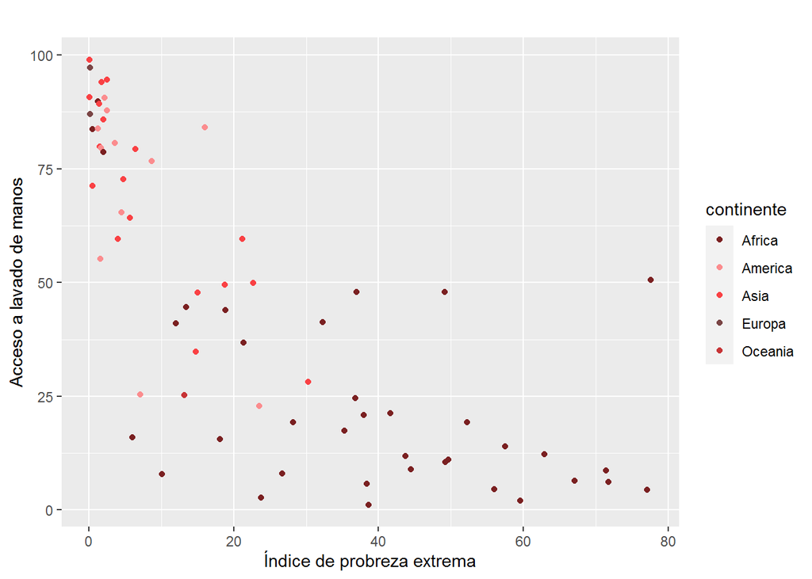

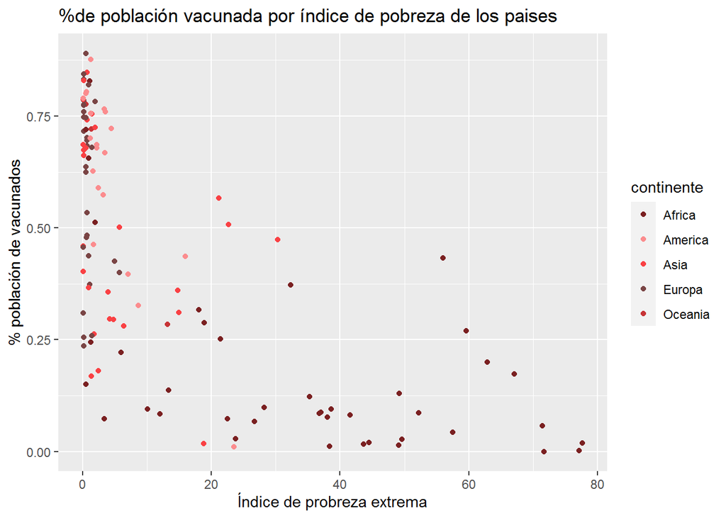

# Variables aleatorias

### 1. Total vacunados. Geométrica

```r
max(PENST$vacunados_completo, na.rm=T)/33000000
```

```
## [1] 0.5460177
```

Razón de ser: este pequeño fragmento de código lo usamos para tener la probabilidad de encontrar una persona vacunada en Perú bajo el supuesto que sigamos siendo casi la misma cantidad de personas.

¿Cuál es la probabilidad de que la décima persona con quien te encuentres en Perú este vacunada?

```r
dgeom(10-1,0.55)
```

```
## [1] 0.0004161744
```

*Análisis:* Al salir de casa ya sea para realizar las compras, ir al trabajo o botar la basura solemos encontrarnos con más de un vecino o alguna persona en el camino por ende colocamos el valor de 10 porque es un promedio aceptable de la cantidad de personas con las que nos podemos encontrar al salir. Podemos observar que la probabilidad de que solo la décima persona que esté cerca de nosotros al salir este vacunada es muy baja.

### 2. Nuevos casos. Binomial.

```
## [1] "Proporción de meses con menos de 50mil casos nuevos de COVID-19 en Perú: 0.29"
```

Calcula la probabilidad de que durante **4 meses** la cantidad de nuevos casos mensuales de covid-19 en Perú no supere a los 50mil, si es que la proporción es de **0.29**.

========================================================

*Éxito*: nuevos casos menor que 50,000.

*Fracaso*: nuevos casos mayor que 50,000.

*Probabilidad de éxito*: 0.29

$P(X=4)$

```r
round(dbinom(4,4,0.29),4)
```

```
## [1] 0.0071
```

*Análisis*: Elegimos la cifra 50mil nuevos contagios, debido a que, durante la primera y segunda ola, hubo incrementos de nuevos casos hasta los picos de más de 200mil mensuales y los periodos más estables no ascendían a más de 50mil casos. El ascenso hasta estos picos se mantuvo alrededor de 4 a 5 meses.

### 3. Nuevas muertes. Binomial

```r
round(100*mean(max(PENST$total_muertes)/max(PENST$total_casos)),2)
```

```
## [1] 9
```

Calcula la probabilidad de no registrar ningún caso de muerte por covid durante 14 días seguidos si la probabilidad de que alguien muera por culpa del covid-19 es de 9%.

```r
dbinom(14,14,0.91)
```

```
## [1] 0.267042
```

*Análisis:* Elegimos 14 días o 2 semanas porque es casi la mitad de un mes y si durante casi la mitad de un mes no se muere ninguna persona por covid-19 significaría que las vacunas tienen un impacto muy eficiente en la reducción de síntomas del covid-19.

# Pruebas de hipótesis

### Hipótesis 1

Para el nivel de confianza realizaremos los cálculos a un nivel de confianza del 90% y del 95%, para poder llegar a una conclusión acerca de cuál de ambos valores nos conviene, decidimos probar con estos valores debido a que la variable tiene valores muy dispersos.

```
## [1] "Mínimo"
```

```
## [1] 1065
```

```
## [1] "Máximo"
```

```
## [1] 250638
```

*Nivel de confianza = 95% por ende nivel de significancia = 0.05*  
*Nivel de confianza = 90% por ende nivel de significancia = 0.1*

```
## [1] "Media muestral"
```

```
## [1] 109283.9
```

La media muestral se obtuvo de nuestra data filtrada para Perú, en donde hallamos la media para los nuevos casos que aparecen mensualmente en el país.

```
## [1] "Desviación Estándar muestral"
```

```
## [1] 87620.04
```

La desviación estándar muestral se obtuvo de nuestra data filtrada para Perú, en donde hallamos la desviación estándar para los nuevos casos que aparecen mensualmente país.

```
## [1] "Tamaño de la muestra"
```

```
## [1] 10
```

```
## [1] "t-estadístico"
```

```
## [1] 0.3350634
```

```
## [1] "Valor-p"
```

```
## [1] 0.6273727
```

Una vez hallado el Valor-P, podemos observar que es mayor que el valor del nivel de significación, lo que significaría que no se debería rechazar la hipótesis nula.

```
## [1] "Punto crítico a = 0.05"
```

```
## [1] -1.833113
```

```
## [1] "Punto crítico a = 0.1"
```

```
## [1] -1.383029
```

Como podemos observar el valor del “t” es mayor que el punto crítico, por lo que la hipótesis nula en primera instancia no sería rechazada.

```
## [1] "Intervalo de confianza"
```

```
## [1] 89462.87
```

```
## [1] 129104.9
```

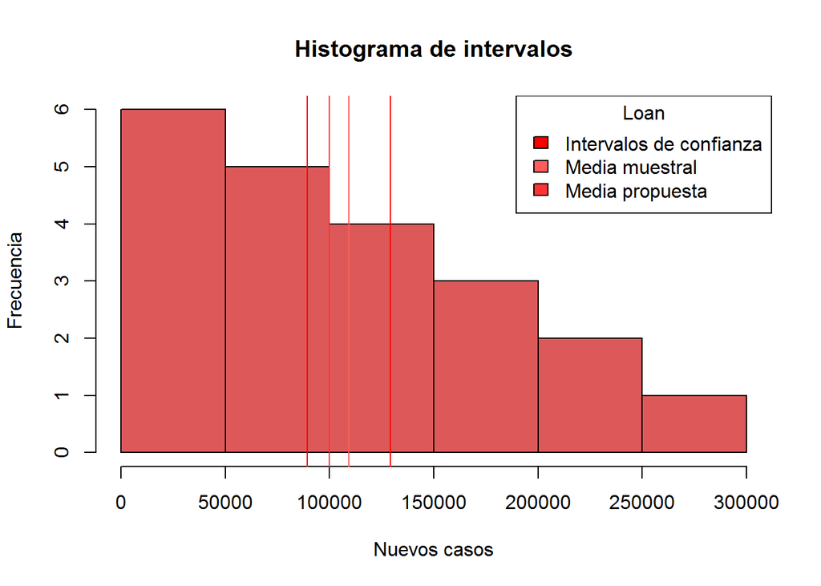

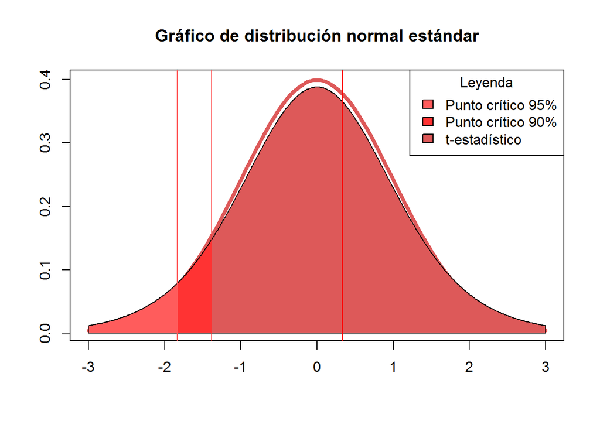

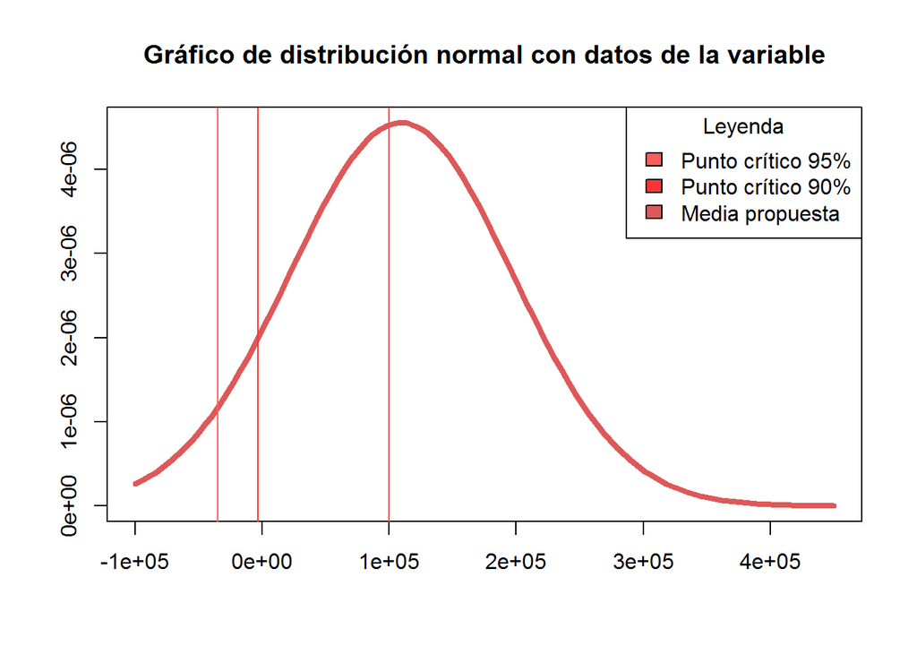

*Análisis:* Como se observa en la gráfica de distribución estándar el valor de t-estadístico hallado se encuentra para ambos casos dentro del área de aceptación, por lo que podríamos usar el intervalo de confianza que más con beneficie dependiendo de qué es lo que queremos lograr, si una mejor precisión o una mayor confiabilidad.

Con un nivel de significancia de 0.05 y 0.1 podemos afirmar que la media de contagios mensuales por COVID-19 en Perú es mayor o igual a 100000.

### Hipótesis 2

Según una investigación realizada por los Centros para el Control y la Prevención de Enfermedades (CDC), afirma que en base a la evidencia de ensayos clínicos realizados a personas de 16 años de edad o más, la vacuna de Pfizer-BioNTech (COMIRNATY) mostró una efectividad del 90 % a más para prevenir casos de infecciones por el virus que causa el COVID-19(https://espanol.cdc.gov/coronavirus/2019-ncov/vaccines/different-vaccines/Pfizer-BioNTech.html). Para poner a prueba esta afirmación se tomó una muestra de 300 personas vacunadas con Pfizer al azar, ya que, al tener casi la mitad de la población peruana vacunada con esta, de las cuales a 280 se pudo observar que no presentaron infección por la enfermedad. Probaremos la afirmación de la investigación a un nivel de confianza del 95%.

```
## [1] "Total de vacunaciones"
```

```
##  [1]   323002  1051815  1833665  4345018  7745490 13557546 19136538 27726853
##  [9] 35252054 40928723
```

En total en el Perú se han registrado más de 40 millones de vacunaciones como indica la tabla presentada, de las cuales más de 10 millones son de la marca Pfizer, por lo cual una muestra de 300 personas vacunadas con esta vacuna es factible de encontrar.

$H_0:$ La efectividad de la vacuna Pfizer es mayor al 90%  
$H_0:$ P>=0.9  
$H_1:$ La efectividad de la vacuna Pfizer es menor al 90%  
$H_1:$ P<0.9

Para poder probar la veracidad de esta hipótesis decidimos utilizar el nivel de confianza al 99% o 95% porque de esta manera podemos acercarnos más hacia la realidad, ya que una vacuna debe ser tanto confiable como tener una precisión aceptable  
*Nivel de confianza = 95% por ende nivel de significancia = 0.05*  
*Nivel de confianza = 99% por ende nivel de significancia = 0.01*

```
## [1] "Z-crítico"
```

```
## [1] 1.924501
```

```
## [1] "Punto crítico 95%"
```

```
## [1] -1.644854
```

[output not shown]

```
## [1] -2.326348
```

Como podemos observar el valor del Z es mayor que el punto crítico, por lo que la hipótesis nula en primera instancia no sería rechazada.

```r
print("Valor-P")
```

```
## [1] "Valor-P"
```

```r
pnorm(q=z, mean=0, sd=1, lower.tail=T)  # Para obtener el valor-P
```

```
## [1] 0.9728541
```

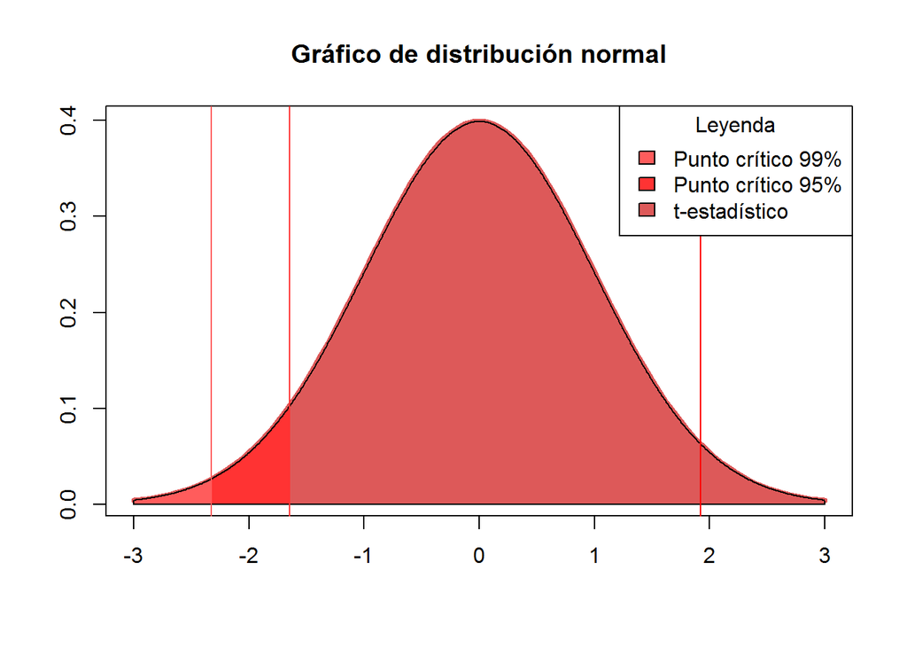

```
## [1] "Intervalos de confianza"
```

```
## [1] 0.9339476
```

```
## [1] 0.8660524
```

*Análisis:* Como se observa en la gráfica el valor de Z-estadístico hallado se encuentra para ambos casos dentro del área de aceptación, por lo que podríamos usar el intervalo de confianza que más con beneficie dependiendo de qué es lo que queremos lograr, si una mejor precisión o una mayor confiabilidad.

Con un nivel de significancia de 0.05 podemos afirmar que la efectividad de la vacuna Pfizer contra el COVID-19 es mayor al 90%.

### Hipótesis 3

$H_0:$ Mensualmente en el Perú se realizan más de 3 millones y medio de vacunaciones, ya que de acuerdo a la información recaudada en Datos macro(https://datosmacro.expansion.com/otros/coronavirus-vacuna/peru)\ $H_0:$ µ>=3500000  
$H_1:$ Mensualmente en el Perú se realizan menos de 3 millones y medio de vacunaciones  
$H_1:$ µ<3500000

Para el nivel de confianza realizaremos los cálculos a un nivel de confianza del 90% y del 95%, para poder llegar a una conclusión acerca de cuál de ambos valores nos conviene, decidimos probar con estos valores debido a que la variable tiene valores muy dispersos.

```
## [1] "Mínimo"
```

```
## [1] 322998
```

```
## [1] "Máximo"
```

```
## [1] 8459637
```

*Nivel de confianza = 95% por ende nivel de significancia = 0.05*  
*Nivel de confianza = 90% por ende nivel de significancia = 0.1*

```r
print("Media Muestral")
```

```
## [1] "Media Muestral"
```

```r
media.muestral
```

```
## [1] 4053031
```

La media muestral se obtuvo de nuestra data filtrada para Perú, en donde hallamos la media para las nuevas vacunaciones que se hacen mensualmente en el país.

```
## [1] "Desviación Estándar muestral"
```

```
## [1] 2927450
```

La desviación estándar muestral se obtuvo de nuestra data filtrada para Perú, en donde hallamos la desviación estándar para las nuevas vacunaciones que se hacen mensualmente en el país.

```
## [1] "Tamaño de la muestra"
```

```
## [1] 10
```

```
## [1] "t-estadístico"
```

```
## [1] 0.5973927
```

Utilizamos el valor de T-estadístico debido a que no teníamos una desviación estándar poblacional conocida, y a su vez al estar separada en meses la data, el número de muestras no es mayor a 30, y solo tenemos 10 muestras, lo que serían 10 meses.

```
## [1] "Valor-p"
```

```
## [1] 0.7175147
```

Una vez hallado el Valor-P, podemos observar que es mayor que el valor del nivel de significación, lo que significaría que no se debería rechazar la hipótesis nula.

```
## [1] "Punto critico a = 0.05"
```

```
## [1] -1.833113
```

```
## [1] "Punto critico a = 0.1"
```

```
## [1] -1.383029
```

Como podemos observar el valor del “t” es mayor que el punto crítico, por lo que la hipótesis nula en primera instancia no sería rechazada.

```
## [1] "Intervalo de confianza"
```

```
## [1] 3390796
```

```
## [1] 4715266
```

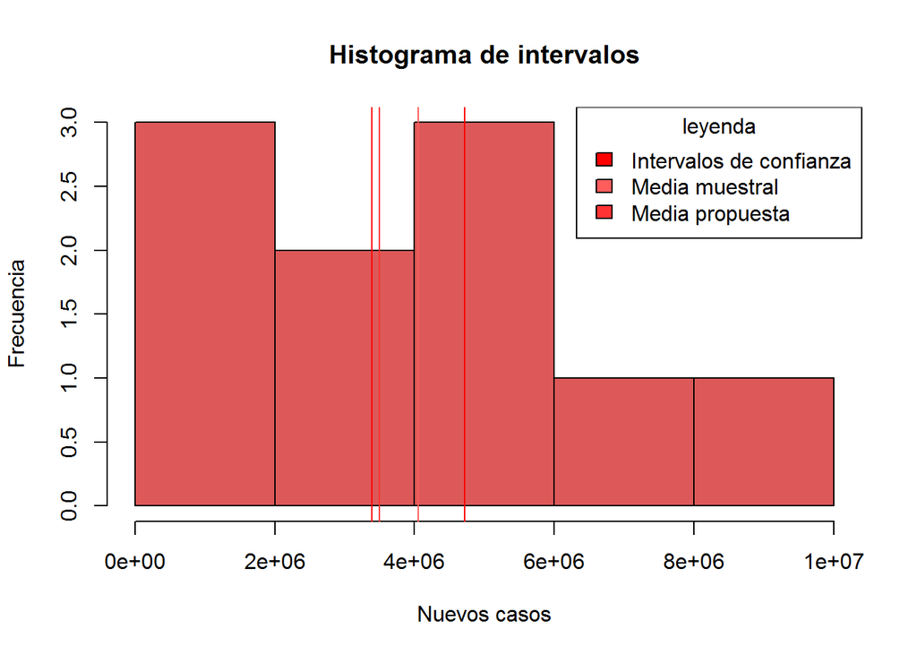

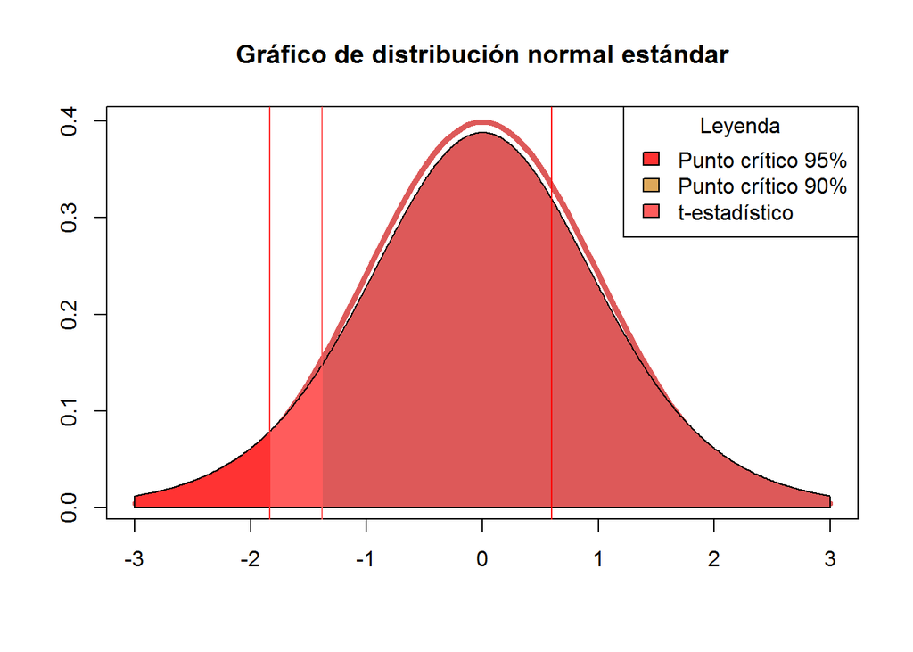

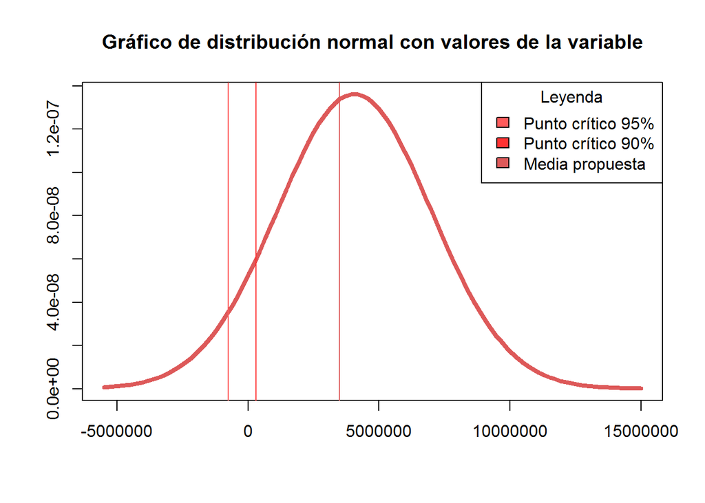

*Análisis:* Como se observa en la gráfica de distribución estándar el valor de t-estadístico hallado se encuentra para ambos casos dentro del área de aceptación, por lo que podríamos usar el intervalo de confianza que más con beneficie dependiendo de qué es lo que queremos lograr, si una mejor precisión o una mayor confiabilidad.

Con un nivel de significancia de 0.05 y 0.1 podemos afirmar que la media de vacunaciones mensuales por COVID-19 en Perú es mayor o igual a 3 millones y medio.

### Análisis Predictivo

#### Regresión 1: Nuevos casos y Nuevas muertes

La variable ‘Cantidad de nuevas muertes’ (nuevas_muertes) representará a la variable dependiente “y” y la variable ‘Cantidad de nuevos casos’ (nuevos_casos) será la variable independiente “x” tanto a nivel mundial como de Perú.

##### Correlación entre las variables

*Mundo:*

*Perú:*

La correlación entre las variables es 0.91, la cual es positiva y fuerte por su cercanía al 1. Esto representa una relación proporcional directa.

##### Coeficientes de regresión

Aplicamos **summary** a la función de modelo lineal (lm) para obtener los coeficientes estimados de la regresión.

*Mundo:*

ßo = 3.104e+05  
ß1 = 1.351e-02  
$y(x) = ß1*x+ßo$  
$y(x) = (1.351e-02)x+(3.104e+05)$

##### R cuadrado

*Mundo:*

*Perú:*

El R-cuadrado resultó 0.83, el cual es mayor a 0.7, los cual indica un buen ajuste del modelo lineal que es capaz de explicar en un 82.7% la variabilidad de nuevas_muertes.

##### Gráfica de regresión

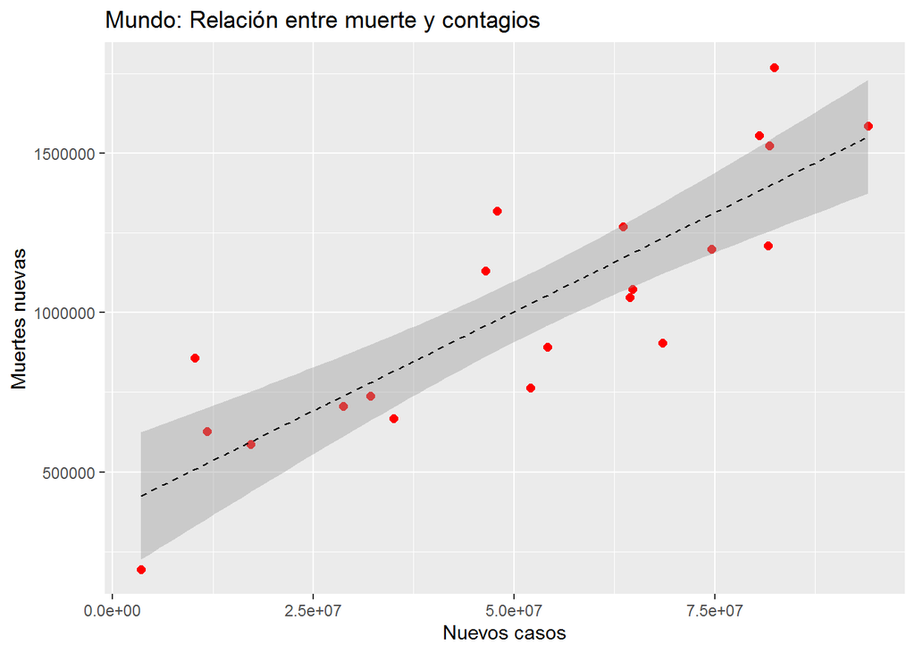

Se utilizó este modelo de regresión lineal debido a que se consideró que a medida que se incrementan la cantidad de casos de personas por Covid-19 (variable independiente), la cantidad de muertes tienden a aumentar (variable dependiente). Esto puede ocurrir debido a que la política de seguridad sanitaria requiere un registro de toda persona diagnosticada con Covid-19 y posterior a eso la persona será tratada. Finalmente se entiende que el incremento de casos de covid-19 explica un incremento en el número de muertes. Además, el p-valor del modelo es significativo (8.112e-08).

```
## [1] "Correlación:  0.86"
```

**Proyecciones**

Tomando los anteriores meses se realizaron una serie de proyecciones de nuevos casos de covid-19, posteriormente se analizaron con la ecuación de regresión obteniendo una variación que concuerda con la relación entre las variables.

```
## [1] "Proyección 1: 64574731 | Muertes:  1182805"
```

```
## [1] "Proyección 2: 66699009 | Muertes:  1211504"
```

```
## [1] "Proyección 3: 66627308 | Muertes:  1210535"
```

```
## [1] "Proyección 4: 62483654 | Muertes:  1154554"
```

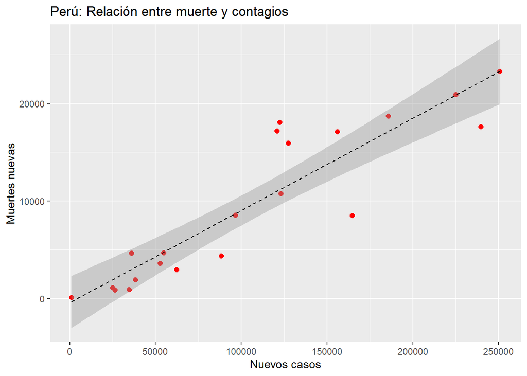

```
## [1] "Correlación:  0.91"
```

Por otro lado, con el gráfico presente podemos observar que conforme aparecen nuevos casos de COVID-19 en el país, la cantidad de muertes sigue en constante aumento, simulando casi una función lineal como muestra su línea de tendencia en el gráfico, lo cual también se reflejado en el valor de la correlación entre ambas variables.

**Proyecciones**

Tomando los anteriores meses se realizaron una serie de proyecciones de nuevos casos de covid-19, posteriormente se analizaron con la ecuación de regresión obteniendo una variación que concuerda con la relación entre las variables.

[output not shown]

[output not shown]

[output not shown]

[output not shown]

### Regresión 2: Hospitalizados y cantidad de muertos

##### Correlación entre las variables

La correlación entre las variables es 0.83, la cual es positiva y cerca al 1. Esto representa una relación proporcional directa o positiva.

##### Coeficientes de regresión

Aplicamos **summary** a la función de modelo lineal (lm) para obtener los coeficientes estimados de la regresión.

ßo = 4.664e+05  
ß1 = 1.477e-01  
$y(x) = ßo +ß1*x$  
$y(x) = (1.477e-01)x+(4.664e+05)$

##### R cuadrado

El R-cuadrado resultó 0.69, lo cual indica que es capaz de explicar en un 69.32% la variabilidad de nuevas_muertes.

##### Gráfica de regresión

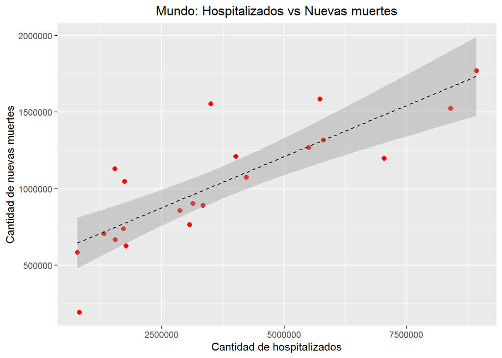

Se utilizó este modelo de regresión lineal debido a que se consideró que a medida que se incrementan la cantidad de casos de personas hospitalizadas (variable independiente), la cantidad de muertes tienden a aumentar (variable dependiente). Esto puede ocurrir debido al presentar los síntomas, las personas buscan ser atendidas a los centros hospitalarios para que le suministren oxígenos y otros tratamientos. Además, el p-valor del modelo es significativo (1.532e-06).

**Proyecciones**

Tomando los anteriores meses se realizaron una serie de proyecciones de nuevos hospitalizados por covid-19, posteriormente se analizaron con la ecuación de regresión obteniendo una variación que concuerda con la relación entre las variables.

```
## [1] "Proyección 1: 3236178 | Muertes:  944383"
```

```
## [1] "Proyección 2: 3288050 | Muertes:  952045"
```

```
## [1] "Proyección 3: 3676925 | Muertes:  1009482"
```

```
## [1] "Proyección 4: 3564514 | Muertes:  992879"
```

### Regresión 3: Cantidad de vacunados y Nuevas muertes

##### Correlación entre las variables

*Mundo:*

*Perú:*

La correlación entre las variables es -0.94, la cual es negativa y fuerte por su cercanía al -1. Esto representa una relación proporcional inversa.

##### Coeficientes de regresión

Aplicamos **summary** a la función de modelo lineal (lm) para obtener los coeficientes estimados de la regresión.

*Perú:*

ßo = 2.178e+04  
ß1 = -2.954e-03  
$y(x) = ßo +ß1*x$  
$y(x) = 2.178e+04-2.954e-03*x$

##### R cuadrado

*Mundo:*

El R-cuadrado resultó 0.35, el cual es bajo, que sólo es capaz de explicar el 35.42% del comportamiento de la variable nuevas_muertes.

##### Gráfica de regresión

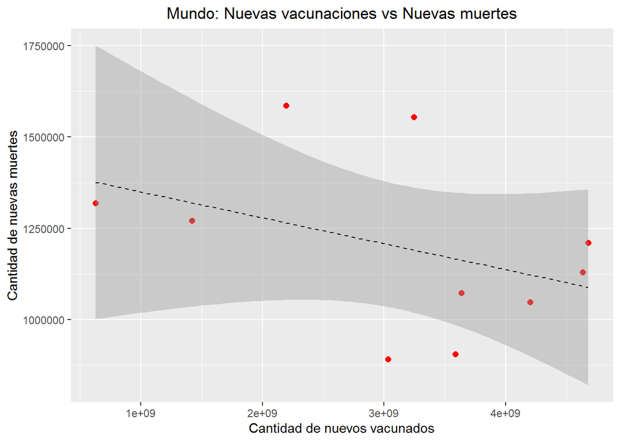

Se utilizó este modelo de regresión lineal debido a que se consideró que a medida que se incrementan la cantidad de personas vacunadas (variable independiente), la cantidad de muertes tienden a disminuir (variable dependiente). Esto se consideró debido a cuantas más personas inmunizadas la probabilidad de sobrellevar el covid-19 incrementaría. Finalmente se obtuvo una relación no tan fuerte, considerando que si se desea analizar el comportamiento de las muertes sería necesario incluir otros factores que no permitan comprender esta variabilidad.

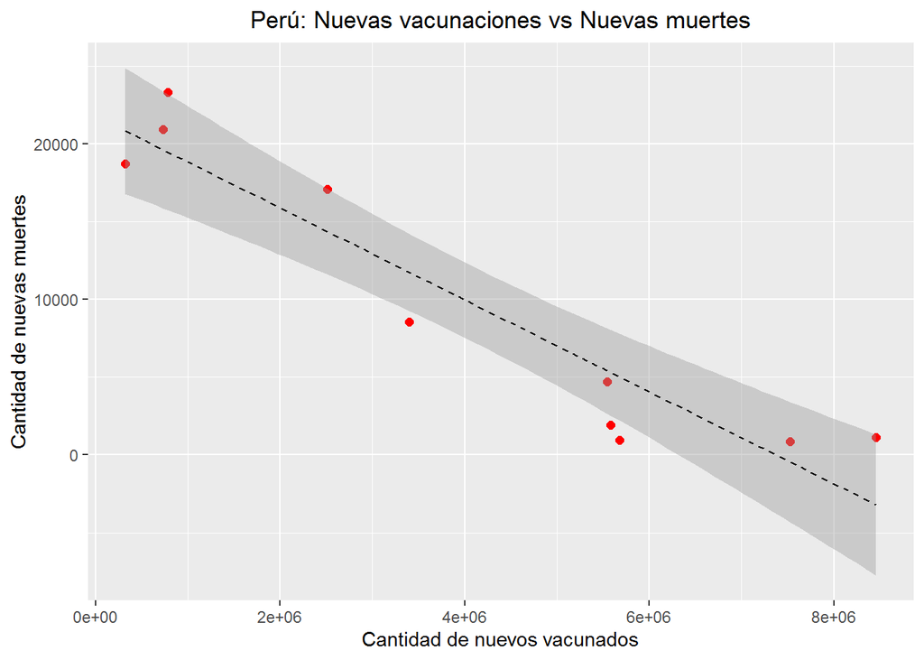

Se utilizó también la regresión lineal para las mismas variables, pero a nivel nacional, esta relación es mucho más fuerte que la de nivel mundial, logrando mostrar que el incremento de las vacunaciones impacta en la cantidad de muertes. Además, el p-valor del modelo es significativo (5.547e-05).

**Proyecciones**

Tomando los anteriores meses se realizaron una serie de proyecciones de nuevos vacunados de covid-19, posteriormente se analizaron con la ecuación de regresión obteniendo una variación que concuerda con la relación entre las variables.

```
## [1] "Proyección 1: 2511353 | Muertes:  14361 0"
```

```
## [1] "Proyección 2: 5544323 | Muertes:  5402 0"
```

```
## [1] "Proyección 3: 781850 | Muertes:  19470 0"
```

Porcentaje de error de la función de regresión

```r
c1 <- PENST$nuevas_muertes[PENST$nuevas_vacunaciones==2511353]
c2 <- PENST$nuevas_muertes[PENST$nuevas_vacunaciones==5544323]
c3 <- PENST$nuevas_muertes[PENST$nuevas_vacunaciones==781850]
print(paste("Error de proyección 1: ",round(100*(c1-14361)/c1,1)))
```

```
## [1] "Error de proyección 1:  15.9"
```

```r
print(paste("Error de proyección 2: ",round(100*(c2-5402)/c2),1))
```

```
## [1] "Error de proyección 2:  -15 1"
```

```r
print(paste("Error de proyección 3: ",round(100*(c3-19470)/c3),1))
```

```
## [1] "Error de proyección 3:  16 1"
```

Con los resultados de los errores de la predicción podemos observar que el error de la función obtenida con la regresión no es mayor a 16.4% por lo que puede predecir

# Conclusiones, reflexiones y recomendaciones

- Perú se ubica en el sexto lugar de países con mayor cantidad de fallecido por covid-19.
- A partir de regresiones y gráficos de dispersión entre variables numéricas pudimos observar patrones y tendencias que permiten obtener predicciones con cierto rango de error.
- Se ha calculado una correlación inversa entre la cantidad de vacunados y muertes a nivel de Perú de -0.94, además se pudo observar una reducción en el número de muertes llegando a las cifras más bajas desde principios de la pandemia.
- Se comprueba la mortalidad de la enfermedad al encontrar una correlación entre nuevos casos y nuevas muertes, con una correlación de 0.86 a nivel mundial y 0.91 en Perú.
- Si al encontrar una base de datos esta tiene más de 20 variables entre las cuales solo te sirven cerca de la mitad o menos lo mejor es crear una nueva data que solo contenga las variables que serán de utilidad para tu estudio para agilizar el análisis de dato.
- Al comparar variables siempre se debe confirmar que ambas variables sean estáticas o cambien con respecto a la misma cantidad de días, meses o años porque de lo contrario los resultados no ayudarían a obtener información alguna por más que parezcan razonables.
- Si la base de datos es demasiado grande llegando a tener más de 50000 observaciones lo mejor es segmentar los datos en el objetivo para trabajar solo con una proporción de los datos y no sobrecargar procesos en la computadora.
- La data brinda información diaria, sin embargo, se necesita acumular la data en un periodo de tiempo, ya que podría generarse desfase debido a que la enfermedad toma un tiempo para desarrollarse causando muertes u hospitalizados e igualmente las vacunas toman un tiempo para inmunizar a las personas. Tomando en cuenta estos periodos, usualmente de 15 días, por esta razón se acumuló la data de forma mensual.